# Clustering KMeans avec R

## Packages à installer

```r
library(dplyr)
library(ggplot2)
library(skimr)
library(cluster)
library(RColorBrewer)
library(kableExtra)
```

# Lecture des données

Lecture d’un fichier csv avec le paramétrage suivant :  
- séparateur de champ : ;  
- séparateur de décimal : .  
- lecture des chaines de caractères en tant que Strings et non Factors

```r
fifa_data<-read.csv2("./fifa_sample.csv",
                           sep=";",stringsAsFactors = FALSE,dec = ".")
```

On affiche le nombre d’individus/variables ainsi que les premières et dernières lignes.

```r
dim(fifa_data)
```

```
## [1] 2993   40
```

```r
fifa_data %>% head(5)
```

```
##       ID Age Overall Crossing Finishing HeadingAccuracy ShortPassing
## 1 189849  29      70       61        68              66           60
## 2 199313  28      72       64        28              62           69
## 3 245993  17      54       42        32              46           57
## 4 224078  25      59       49        43              59           59
## 5 232171  25      65       48        52              43           62
##   Volleys Dribbling Curve FKAccuracy LongPassing BallControl Acceleration
## 1      70        71    68         70          55          70           69
## 2      49        61    58         49          65          69           80
## 3      33        54    39         34          50          52           62
## 4      41        57    45         42          60          62           66
## 5      39        67    47         47          59          63           74
##   SprintSpeed Agility Reactions Balance ShotPower Jumping Stamina Strength
## 1          76      70        68      67        74      80      67       75
## 2          79      78        68      66        50      75      81       72
```

[output cut: 27 more lines]

```r
fifa_data %>% tail(5)
```

```
##          ID Age Overall Crossing Finishing HeadingAccuracy ShortPassing
## 2989 183394  28      NA       75        69              70           79
## 2990 242591  18      NA       18        54              47           35
## 2991 162054  33      NA       14        15              11           18
## 2992 137406  35      NA       68        51              50           69
## 2993 234035  22      NA       81        45              73           77
##      Volleys Dribbling Curve FKAccuracy LongPassing BallControl
## 2989      64        82    75         74          74          77
## 2990      34        39    36         28          20          47
## 2991      11        16    13         16          43          34
## 2992      51        71    61         59          65          70
## 2993      48        69    69         30          70          77
##      Acceleration SprintSpeed Agility Reactions Balance ShotPower Jumping
## 2989           79          81      67        74      58        85      78
## 2990           54          57      55        47      61        52      65
```

[output cut: 27 more lines]

# Exploration des données

## Visualisation synthétique

L’objectif est de disposer rapidement d’une synthèse statistiques de nos données : moyenne, écart_type, percentiles et histogrammes.  
Nous voyons que la variable ID est identifiée comme numérique, il faudra en tenir compte lors de notre modélisation. Les variables ont des échelles différentes.  
On constate que certaines colonnes ont des valeurs manquantes.

```r
skimr::skim(fifa_data)
```

Data summary

| Name | fifa_data |
| --- | --- |
| Number of rows | 2993 |
| Number of columns | 40 |
| _______________________ |  |
| Column type frequency: |  |
| character | 3 |
| numeric | 37 |
| ________________________ |  |
| Group variables | None |

**Variable type: character**

| skim_variable | n_missing | complete_rate | min | max | empty | n_unique | whitespace |
| --- | --- | --- | --- | --- | --- | --- | --- |
| Name | 0 | 1 | 4 | 23 | 0 | 2947 | 0 |
| Club | 0 | 1 | 0 | 35 | 38 | 647 | 3 |
| PositionGroup | 0 | 1 | 2 | 7 | 0 | 5 | 0 |

**Variable type: numeric**

| skim_variable | n_missing | complete_rate | mean | sd | p0 | p25 | p50 | p75 | p100 | hist |
| --- | --- | --- | --- | --- | --- | --- | --- | --- | --- | --- |
| ID | 0 | 1.00 | 214358.45 | 28889.98 | 5479 | 200356 | 221394 | 236353 | 246616 |  |
| Age | 50 | 0.98 | 25.17 | 4.67 | 16 | 21 | 25 | 29 | 44 |  |
| Overall | 50 | 0.98 | 66.35 | 6.81 | 47 | 62 | 66 | 71 | 91 |  |
| Crossing | 0 | 1.00 | 50.17 | 18.07 | 8 | 39 | 54 | 64 | 91 |  |
| Finishing | 0 | 1.00 | 45.74 | 19.03 | 2 | 31 | 49 | 61 | 87 |  |
| HeadingAccuracy | 0 | 1.00 | 52.57 | 17.07 | 5 | 45 | 56 | 64 | 94 |  |
| ShortPassing | 0 | 1.00 | 59.01 | 14.46 | 12 | 54 | 62 | 68 | 91 |  |
| Volleys | 0 | 1.00 | 43.03 | 17.37 | 4 | 30 | 44 | 56 | 90 |  |
| Dribbling | 0 | 1.00 | 55.50 | 18.63 | 4 | 49 | 61 | 68 | 95 |  |
| Curve | 0 | 1.00 | 47.55 | 18.05 | 6 | 35 | 49 | 62 | 89 |  |
| FKAccuracy | 0 | 1.00 | 43.05 | 17.20 | 6 | 31 | 42 | 56 | 90 |  |
| LongPassing | 0 | 1.00 | 53.30 | 14.98 | 10 | 44 | 56 | 64 | 89 |  |
| BallControl | 0 | 1.00 | 58.60 | 16.42 | 5 | 54 | 63 | 69 | 94 |  |
| Acceleration | 0 | 1.00 | 64.60 | 14.69 | 15 | 57 | 67 | 75 | 97 |  |
| SprintSpeed | 0 | 1.00 | 64.84 | 14.38 | 15 | 57 | 67 | 75 | 96 |  |
| Agility | 0 | 1.00 | 63.43 | 14.44 | 21 | 56 | 66 | 73 | 95 |  |
| Reactions | 0 | 1.00 | 61.86 | 9.10 | 21 | 56 | 62 | 68 | 93 |  |
| Balance | 0 | 1.00 | 63.82 | 14.04 | 16 | 56 | 66 | 74 | 96 |  |
| ShotPower | 0 | 1.00 | 55.77 | 16.88 | 3 | 46 | 59 | 68 | 93 |  |
| Jumping | 0 | 1.00 | 64.91 | 11.85 | 26 | 58 | 66 | 73 | 93 |  |
| Stamina | 0 | 1.00 | 63.43 | 15.64 | 13 | 56 | 67 | 74 | 96 |  |
| Strength | 0 | 1.00 | 65.70 | 12.34 | 25 | 58 | 67 | 74 | 94 |  |
| LongShots | 0 | 1.00 | 47.26 | 18.89 | 5 | 33 | 52 | 62 | 92 |  |
| Aggression | 0 | 1.00 | 56.49 | 17.18 | 11 | 45 | 59 | 70 | 95 |  |
| Interceptions | 0 | 1.00 | 47.37 | 20.81 | 4 | 26 | 54 | 65 | 92 |  |
| Positioning | 0 | 1.00 | 50.19 | 19.12 | 2 | 39 | 55 | 65 | 92 |  |
| Vision | 0 | 1.00 | 53.39 | 13.96 | 10 | 44 | 55 | 64 | 91 |  |
| Penalties | 0 | 1.00 | 48.66 | 15.45 | 9 | 39 | 49 | 60 | 92 |  |
| Composure | 0 | 1.00 | 58.73 | 11.43 | 3 | 51 | 60 | 67 | 93 |  |
| Marking | 0 | 1.00 | 48.12 | 19.85 | 5 | 30 | 54 | 65 | 90 |  |
| StandingTackle | 0 | 1.00 | 48.52 | 21.62 | 5 | 27 | 56 | 66 | 91 |  |
| SlidingTackle | 0 | 1.00 | 46.54 | 21.18 | 7 | 25 | 53 | 64 | 88 |  |
| GKDiving | 0 | 1.00 | 16.16 | 17.33 | 1 | 8 | 11 | 14 | 88 |  |
| GKHandling | 0 | 1.00 | 15.91 | 16.49 | 1 | 8 | 11 | 14 | 84 |  |
| GKKicking | 0 | 1.00 | 15.84 | 16.01 | 1 | 8 | 11 | 14 | 80 |  |
| GKPositioning | 0 | 1.00 | 16.02 | 16.56 | 1 | 8 | 11 | 14 | 85 |  |
| GKReflexes | 0 | 1.00 | 16.33 | 17.55 | 1 | 8 | 11 | 14 | 92 |  |

## Visualisation pour une variable donnée

Nous réalisons ici un graphe de distribution de la variable overall.

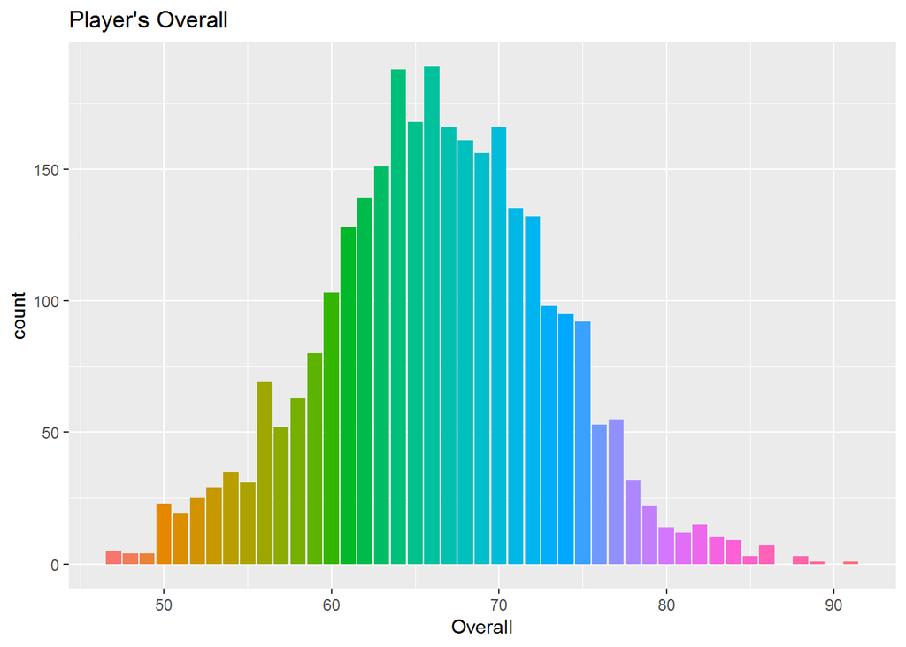

```r
fifa_data %>%
  ggplot(aes(x = Overall, fill = factor(Overall))) +
  geom_bar() + guides(fill = FALSE)+
  labs(title="Player's Overall ")
```

Ce graphe croise les variables age et overall. On observe un lien entre l’age et la note globale du joueur.

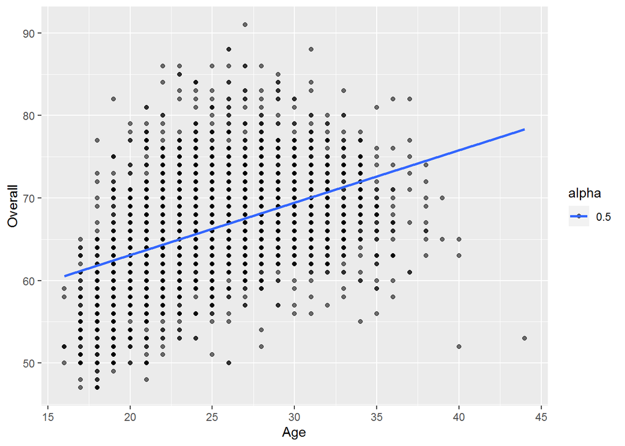

```r
fifa_data %>%
  ggplot(aes(x = Age,y=Overall,alpha=0.5)) +
  geom_point()  +
  geom_smooth(method = "lm", se = FALSE)
```

La fonction suivante permet de réaliser des “pairwise” graphiques.

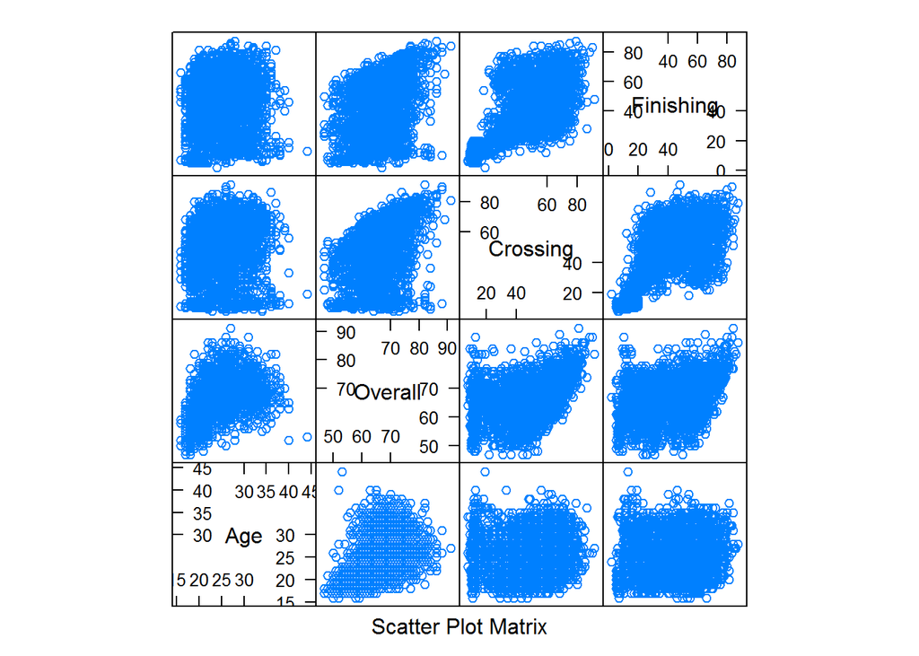

```r
lattice::splom(fifa_data[2:5])
```

# Traitement préparatoire des données

## Remplacement des valeurs manquantes par la moyenne

On constate des valeurs manquantes sur deux variables : Age, Overall

```r
fifa_data %>%
  summarise_all(funs(sum(is.na(.)))) %>% glimpse
```

```
## Observations: 1
## Variables: 40
## $ ID              <int> 0
## $ Age             <int> 50
## $ Overall         <int> 50
## $ Crossing        <int> 0
## $ Finishing       <int> 0
## $ HeadingAccuracy <int> 0
## $ ShortPassing    <int> 0
## $ Volleys         <int> 0
## $ Dribbling       <int> 0
## $ Curve           <int> 0
## $ FKAccuracy      <int> 0
## $ LongPassing     <int> 0
## $ BallControl     <int> 0
```

[output cut: 27 more lines]

On créé un dataframe qui contient les valeurs des moyennes pour les variables étudiées.

```r
(mean.df<-fifa_data %>%
  select(Age,Overall) %>%
  summarize(Age_mean=round(mean(Age,na.rm=TRUE),0),
            Overall_mean=round(mean(Overall,na.rm=TRUE),0))
)
```

```
##   Age_mean Overall_mean
## 1       25           66
```

On remplace les valeurs manquantes dans le dataframe.

```r
fifa_data.fillna<-fifa_data %>%
  mutate(Age=ifelse(is.na(Age),mean.df$Age_mean,Age),
         Overall=ifelse(is.na(Overall),mean.df$Overall_mean,Overall)
         )
```

On vérifie le nombre de valeurs manquantes.

```r
fifa_data.fillna %>%
  summarise_all(funs(sum(is.na(.)))) %>% glimpse
```

```
## Observations: 1
## Variables: 40
## $ ID              <int> 0
## $ Age             <int> 0
## $ Overall         <int> 0
## $ Crossing        <int> 0
## $ Finishing       <int> 0
## $ HeadingAccuracy <int> 0
## $ ShortPassing    <int> 0
## $ Volleys         <int> 0
## $ Dribbling       <int> 0
## $ Curve           <int> 0
## $ FKAccuracy      <int> 0
## $ LongPassing     <int> 0
## $ BallControl     <int> 0
```

[output cut: 27 more lines]

## Scaling des variables

Le dataset n’ayant plus de valeurs manquantes, on peut procéder au scaling des données. On ne sélectionne que les colonnes numériques `select_if(is.numeric)`. On perd les variables `name`, `Club` et `groupPosition`.

```r
fifa_data.numeric<-fifa_data.fillna %>% select_if(is.numeric)
fifa_data.fillna.scaled<-fifa_data.numeric  %>%
  scale( center = TRUE, scale = TRUE) %>%
  as.data.frame

fifa_data.numeric %>% select(1:4)%>% summary
```

```
##        ID              Age           Overall         Crossing
##  Min.   :  5479   Min.   :16.00   Min.   :47.00   Min.   : 8.00
##  1st Qu.:200356   1st Qu.:21.00   1st Qu.:62.00   1st Qu.:39.00
##  Median :221394   Median :25.00   Median :66.00   Median :54.00
##  Mean   :214358   Mean   :25.17   Mean   :66.34   Mean   :50.17
##  3rd Qu.:236353   3rd Qu.:28.00   3rd Qu.:71.00   3rd Qu.:64.00
##  Max.   :246616   Max.   :44.00   Max.   :91.00   Max.   :91.00
```

```r
fifa_data.fillna.scaled %>% select(1:4) %>% summary
```

```
##        ID               Age              Overall            Crossing
##  Min.   :-7.2302   Min.   :-1.97911   Min.   :-2.86500   Min.   :-2.3335
##  1st Qu.:-0.4847   1st Qu.:-0.90011   1st Qu.:-0.64286   1st Qu.:-0.6181
##  Median : 0.2435   Median :-0.03692   Median :-0.05029   Median : 0.2120
##  Mean   : 0.0000   Mean   : 0.00000   Mean   : 0.00000   Mean   : 0.0000
##  3rd Qu.: 0.7613   3rd Qu.: 0.61048   3rd Qu.: 0.69042   3rd Qu.: 0.7654
##  Max.   : 1.1166   Max.   : 4.06327   Max.   : 3.65328   Max.   : 2.2595
```

Autre possibilité de scaling : Min/Max scaling (les valeurs seront comprises entre 0 et 1). On retiendra ce scaking des données pour notre kmeans.

```r
normalize <- function(x) {
    return ((x - min(x)) / (max(x) - min(x)))
}

fifa_data.scaled.minMax <- as.data.frame(lapply(fifa_data.numeric, normalize))
fifa_data.scaled.minMax %>% select(1:5) %>% summary
```

```
##        ID              Age            Overall          Crossing
##  Min.   :0.0000   Min.   :0.0000   Min.   :0.0000   Min.   :0.0000
##  1st Qu.:0.8082   1st Qu.:0.1786   1st Qu.:0.3409   1st Qu.:0.3735
##  Median :0.8954   Median :0.3214   Median :0.4318   Median :0.5542
##  Mean   :0.8662   Mean   :0.3275   Mean   :0.4395   Mean   :0.5081
##  3rd Qu.:0.9574   3rd Qu.:0.4286   3rd Qu.:0.5455   3rd Qu.:0.6747
##  Max.   :1.0000   Max.   :1.0000   Max.   :1.0000   Max.   :1.0000
##    Finishing
##  Min.   :0.0000
##  1st Qu.:0.3412
##  Median :0.5529
##  Mean   :0.5146
##  3rd Qu.:0.6941
##  Max.   :1.0000
```

# KMeans

On applique la kmeans sur le dataframe avec toutes les variables.

```r
#on sélectionne le dataframe qu'on veut utiliser
df.for.kmeans<-fifa_data.scaled.minMax
```

```r
#on teste avec k = 3
clusters <- kmeans(fifa_data.scaled.minMax, 3, nstart = 100)
clusters$tot.withinss  # variance intra
```

```
## [1] 1867.275
```

```r
clusters$size          # taille des clusters
```

```
## [1] 1085 1597  311
```

On cherche la bonne valeur de k avec la méthode du coude.

```r
#on créé une fonction qui retourne la variance intra pour une valeur de k
kmean_withinss <- function(k) {
  print(paste0("kmeans k:",k))
  cluster <- kmeans(df.for.kmeans, k, nstart = 50)
  return (cluster$tot.withinss)
}
# Set maximum cluster
max_k <-10
# Run algorithm over a range of k
wss <- sapply(2:max_k, kmean_withinss)
```

```
## [1] "kmeans k:2"
## [1] "kmeans k:3"
## [1] "kmeans k:4"
## [1] "kmeans k:5"
## [1] "kmeans k:6"
## [1] "kmeans k:7"
## [1] "kmeans k:8"
## [1] "kmeans k:9"
## [1] "kmeans k:10"
```

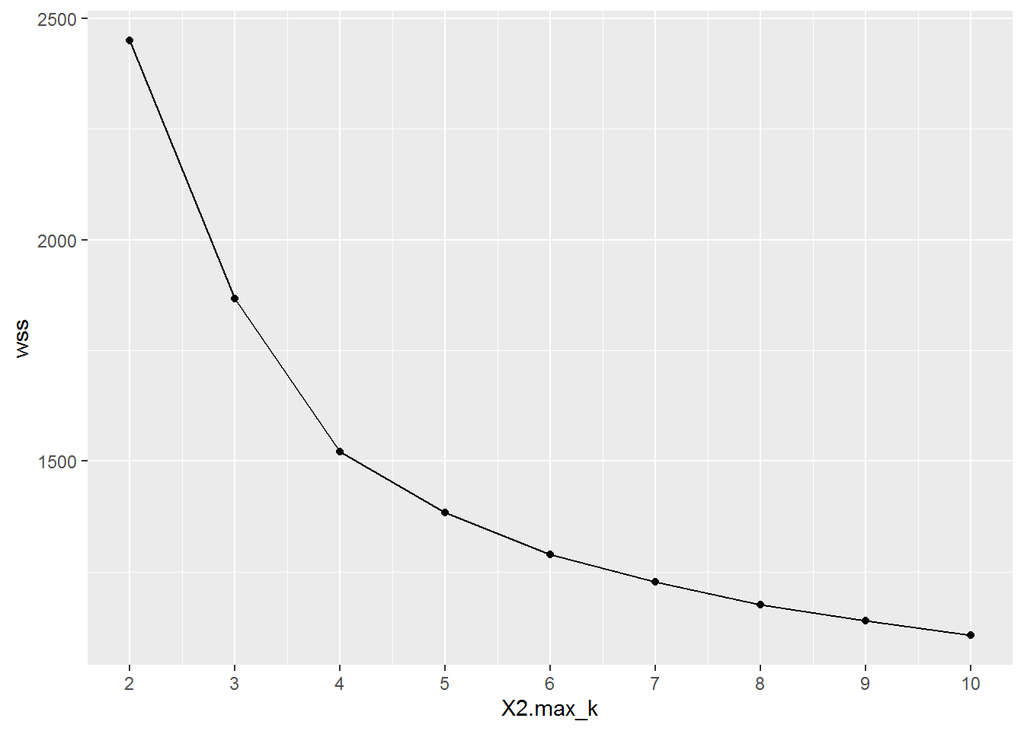

```r
# Create a data frame to plot the graph
elbow <-data.frame(2:max_k, wss)
# Plot the graph with gglop
ggplot(elbow, aes(x = X2.max_k, y = wss)) +
  geom_point() +
  geom_line() +
  scale_x_continuous(breaks = seq(1, max_k, by = 1))
```

On cherche la bonne valeur de k avec la méthode de la silouhette.

```r
# function to compute average silhouette for k clusters
library(cluster)
avg_sil <- function(k) {
  print(paste0("silhouette k:",k))
  km.res <- kmeans(df.for.kmeans, centers = k, nstart = 50)
  ss <- silhouette(km.res$cluster, dist(df.for.kmeans))
  return(mean(ss[, 3]))
}
# Set maximum cluster
max_k <-10

# Run algorithm over a range of k
avg.silhouette <- sapply(2:max_k, avg_sil)
```

```
## [1] "silhouette k:2"
## [1] "silhouette k:3"
## [1] "silhouette k:4"
## [1] "silhouette k:5"
## [1] "silhouette k:6"
## [1] "silhouette k:7"
## [1] "silhouette k:8"
## [1] "silhouette k:9"
## [1] "silhouette k:10"
```

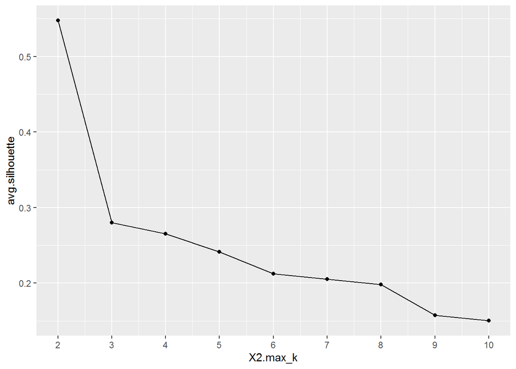

```r
# Create a data frame to plot the graph
silhouette <-data.frame(2:max_k, avg.silhouette)
# Plot the graph
ggplot(silhouette, aes(x = X2.max_k, y = avg.silhouette)) +
  geom_point() +
  geom_line() +
  scale_x_continuous(breaks = seq(1, max_k, by = 1))
```

Le meilleur clustering est de 2 clusters.

Ques se passe-t-il ?  
Regardons la composition des clusters sur les différentes variables.  
Pour cela, on recalcule la kmeans sur 2 clusters puis on affecte les clusters au dataframe d’origine.

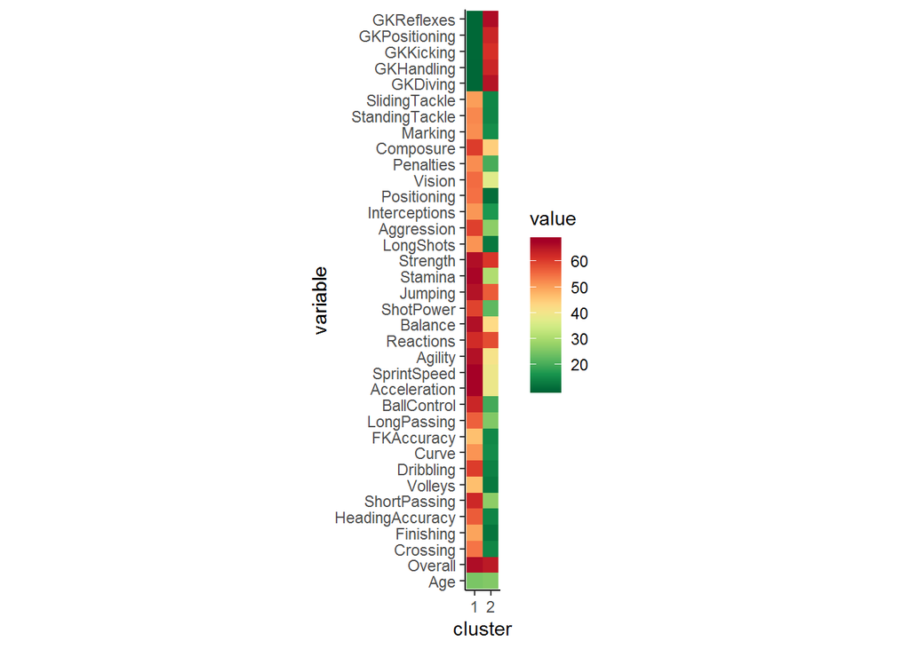

```r
#affectation de la kmeans
clusters.final <- kmeans(fifa_data.scaled.minMax, 2, nstart = 100)
cluster<-clusters.final$cluster
fifa_with_cluster<-fifa_data.fillna %>% cbind(cluster)

#calcul des stats
stats<-fifa_with_cluster %>%select_if(is.numeric) %>% select(-ID) %>%
  group_by(cluster) %>%
  summarise_all("mean")
stats.reshaped<-reshape2::melt(stats, id.vars="cluster")

# create the heatmap
## palette
hm.palette <-colorRampPalette(rev(brewer.pal(10, 'RdYlGn')),space='Lab')
ggplot(data = stats.reshaped, aes(x = cluster, y =variable, fill = value)) +
  scale_x_continuous(breaks = seq(1, 8, by = 1)) +
  geom_tile() +
  coord_equal() +
  scale_fill_gradientn(colours = hm.palette(90)) +
  theme_classic()
```

```r
fifa_with_cluster %>%
  group_by(cluster,PositionGroup) %>%
  count()
```

```
## # A tibble: 5 x 3
## # Groups:   cluster, PositionGroup [5]
##   cluster PositionGroup     n
##     <int> <chr>         <int>
## 1       1 DEF            1020
## 2       1 FWD             546
## 3       1 MID            1114
## 4       1 Unknown           2
## 5       2 GK              311
```

On constate que la kmeans avec deux clusters distingue les gardiens des autres joueurs !  
Est-ce que plus de clusters permettraient de distinguer toutes les catégories de joueurs ?  
Quel pré-traitement de données pourrait-on appliquer ?